# R Notebook

```r
library(Stat2Data)
data("HighPeaks")
```

———- BEGIN HIGH PEAKS SECTION ————

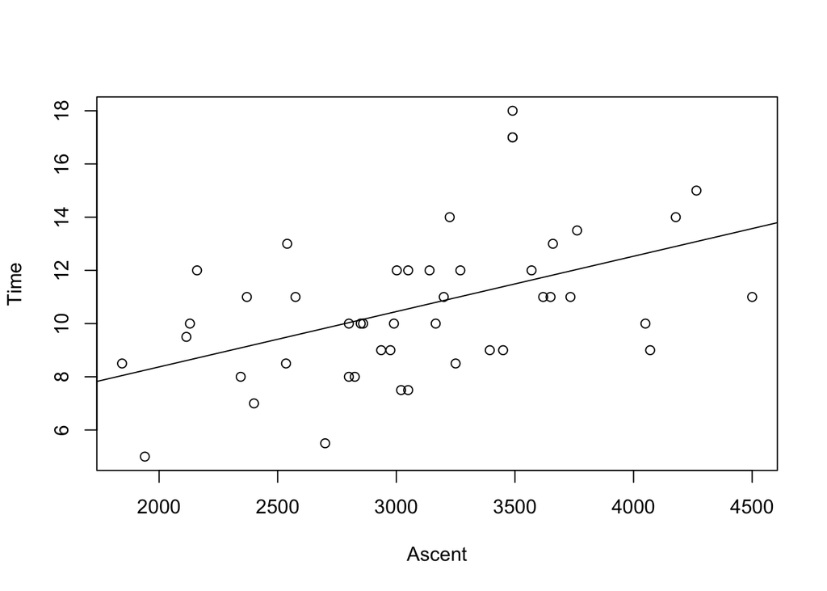

```r
# (PART A, PART B)

# Part B
plot(Time~Ascent, data=HighPeaks)
mod1=lm(Time~Ascent, data=HighPeaks)
abline(mod1)
```

```r
#Part A
summary(mod1) # Find equation for least squares line
```

```
##
## Call:
## lm(formula = Time ~ Ascent, data = HighPeaks)
##
## Residuals:
##    Min     1Q Median     3Q    Max
## -4.327 -2.075 -0.150  1.414  6.529
##
## Coefficients:
##              Estimate Std. Error t value Pr(>|t|)
## (Intercept) 4.2100541  1.8661683   2.256  0.02909 *
## Ascent      0.0020805  0.0005909   3.521  0.00101 **
## ---
## Signif. codes:  0 '***' 0.001 '**' 0.01 '*' 0.05 '.' 0.1 ' ' 1
##
## Residual standard error: 2.496 on 44 degrees of freedom
## Multiple R-squared:  0.2198, Adjusted R-squared:  0.2021
## F-statistic:  12.4 on 1 and 44 DF,  p-value: 0.001014
```

(PART A) Least Squares Regression Line: 4.2100541 + 0.0020805x

(PART B) See scatterplot with least squares line above

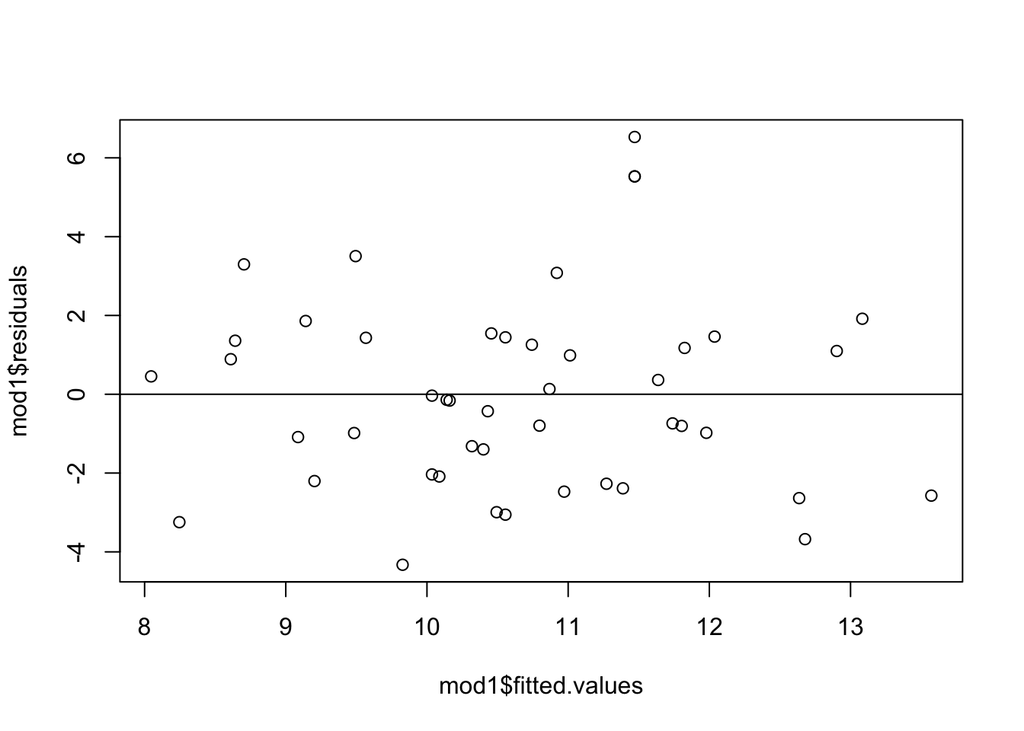

```r
# (PART C, PART D)

plot(mod1$residuals~mod1$fitted.values)
abline(0,0)
```

```r
HighPeaks[46,] #Couchsachraga Peak (need to do name without space)
```

|  | Peak | Elevation | Difficulty | Ascent | Length | Time |
| --- | --- | --- | --- | --- | --- | --- |
| 46 | Couchsachraga Peak | 3820 | 6 | 3140 | 15 | 12 |

```r
max(mod1$residuals) # Largest (pos.) resdual = 6.528913
```

```
## [1] 6.528913
```

```r
which.max(mod1$residuals) # Largest (pos.) residual found at HighPeaks[40]
```

```
## 40
## 40
```

```r
HighPeaks[40,] # Finds peak with residual 6.528913
```

|  | Peak | Elevation | Difficulty | Ascent | Length | Time |
| --- | --- | --- | --- | --- | --- | --- |
| 40 | Mt. Emmons | 4040 | 7 | 3490 | 18 | 18 |

```r
min(mod1$residuals) # Largest (neg.) resdual = -4.327472
```

```
## [1] -4.327472
```

```r
which.min(mod1$residuals) # Largest (neg.) residual found at HighPeaks[38]
```

```
## 38
## 38
```

```r
HighPeaks[38,] # Finds peak with residual -4.327472
```

|  | Peak | Elevation | Difficulty | Ascent | Length | Time |
| --- | --- | --- | --- | --- | --- | --- |
| 38 | Porter Mtn. | 4059 | 3 | 2700 | 7.6 | 5.5 |

(PART D) Mountain with largest positive residual: Mt. Emmons Value of largest positive residual: 6.528913

(PART E) Mountain with largest negative residual: Porter Mtn. Value of largest negative residual: -4.327472

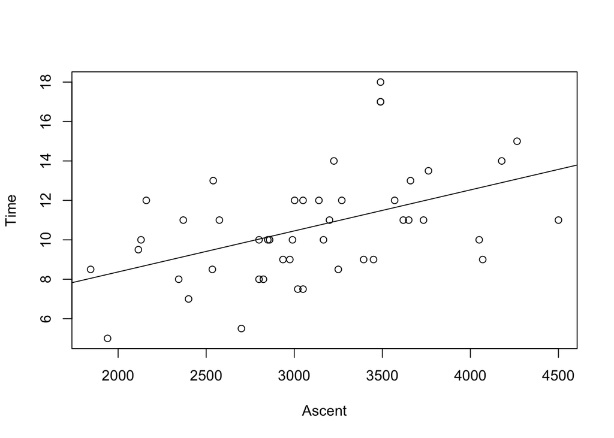

```r
# (PART E)

# PLOT 1 (Check for linearity, constant variance)
plot(Time~Ascent, data=HighPeaks)
abline(mod1)
```

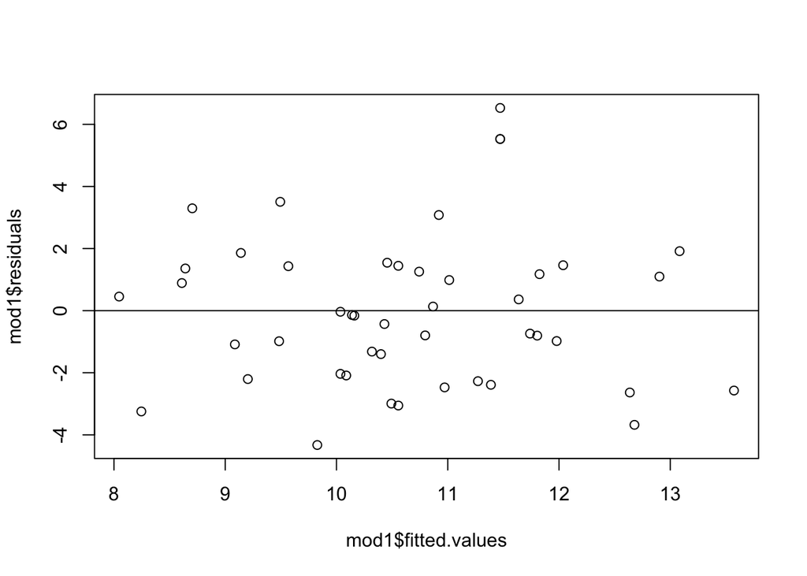

```r
# PLOT 2 (Check for zero mean)
plot(mod1$residuals~mod1$fitted.values)
abline(0,0)
```

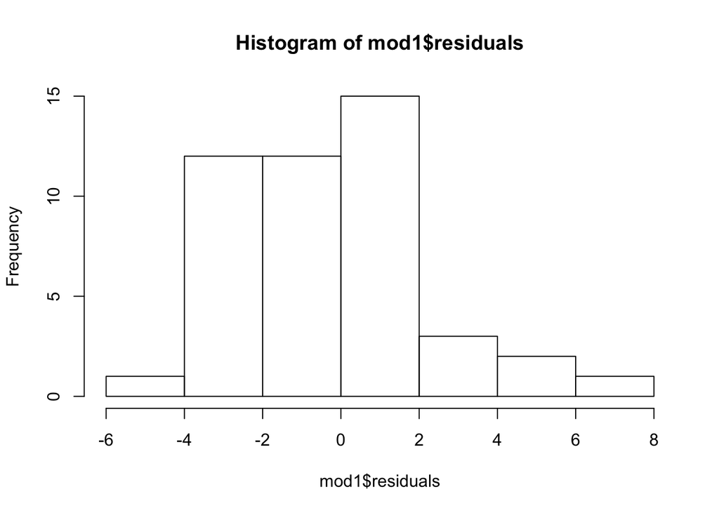

```r
# PLOT 3 (Check for independence, normal residuals)
hist(mod1$residuals)
```

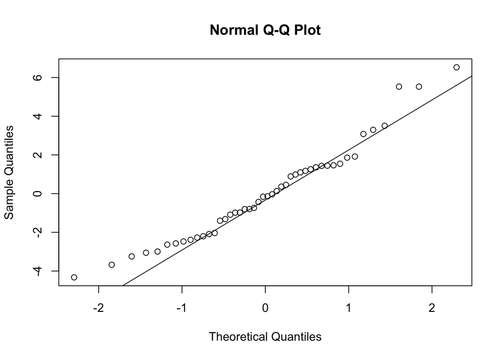

```r
# PLOT 4 (Check for independence, normal residuals)
qqnorm(mod1$residuals)
qqline(mod1$residuals)
```

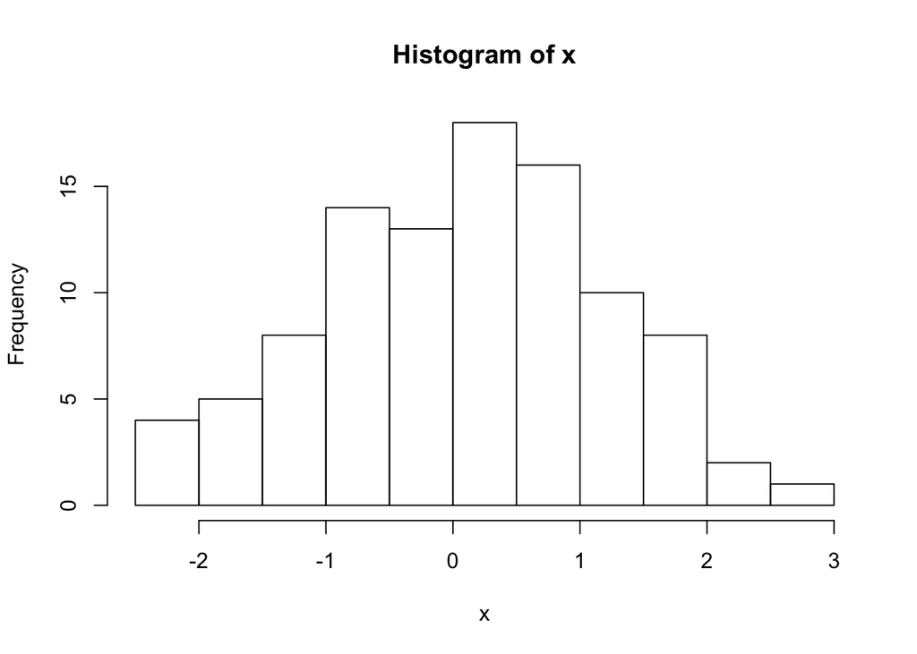

```r
# PLOT 5 (Check for normality)
set.seed(439218)
x = sort(rnorm(99,0,1))
hist(x)
```

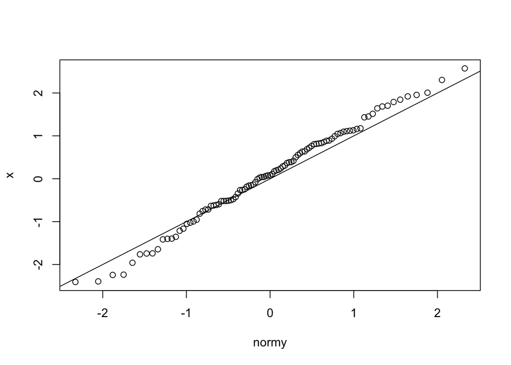

```r
# PLOT 6 (Check for normality)
y = c(1:99)
normy = qnorm(y/100)
plot(x~normy)
abline(0,1)
```

(PART E)

Plot 1 (plot with fitted line) allows us to quickly check for normality and constance variance. Time appears to vary linearly with ascent and there is no clear “fanning” pattern, so we can assume the model has linearity and constance variance.

Plot 2 (plot with fitted line - residuals) helps us check for a zero mean with respect to the residuals. At a glance, the residuals do not appear to explicitly vary around a line other than 0, so we can also assume a zero mean.

Plots 3 and 4 allow us to investigate independence, or whether the residuals appear normal. The histogram (Plot 3) appears to skew right slightly, and the qq norm plot (Plot 4) seems to curve off slightly at the extremities about the qq line. However, the residuals seem to follow normal distribution reasonably well and there isnt a CLEAR outlier or skew, so we can say (within a reasonable doubt) that the model shows independence.

Plots 5 and 6 check for normality. Taking a random sample of 99 values from a normal distribution, we can see through Plot 5 (histogram) that the sample exhibits fairly clear normality, and Plot 6 (plot with fitted line) also displays pretty clear normality with its values fitted realtively closely about the line. Thus, we can say the model is normal.

So, with the exception of some doubt regarding the independence, the model meets the conditions for a simple linear model.

———– END HIGH PEAKS SECTION ————-

```r
data("Perch")
```

———— BEGIN PERCH SECTION ————–

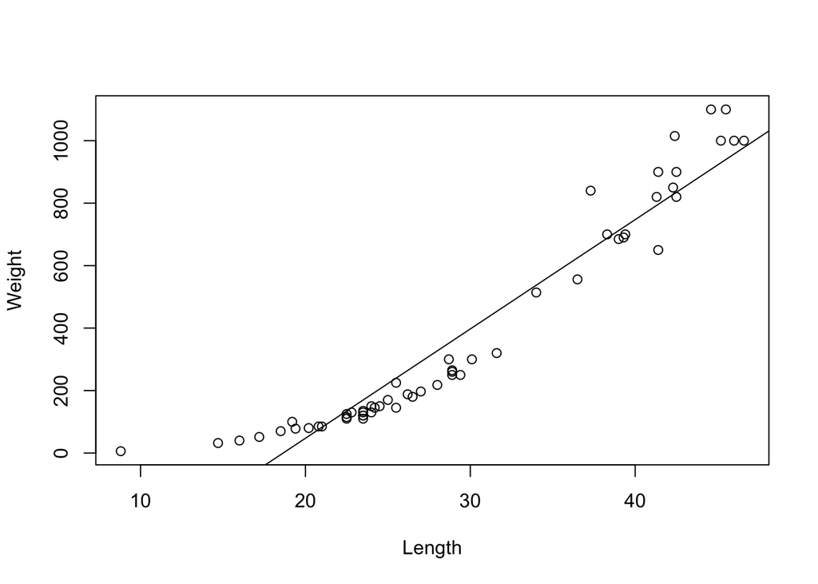

```r
# (PART A)

# PLOT 1
plot(Weight~Length, data=Perch)
mod2=lm(Weight~Length, data=Perch)
abline(mod2)
```

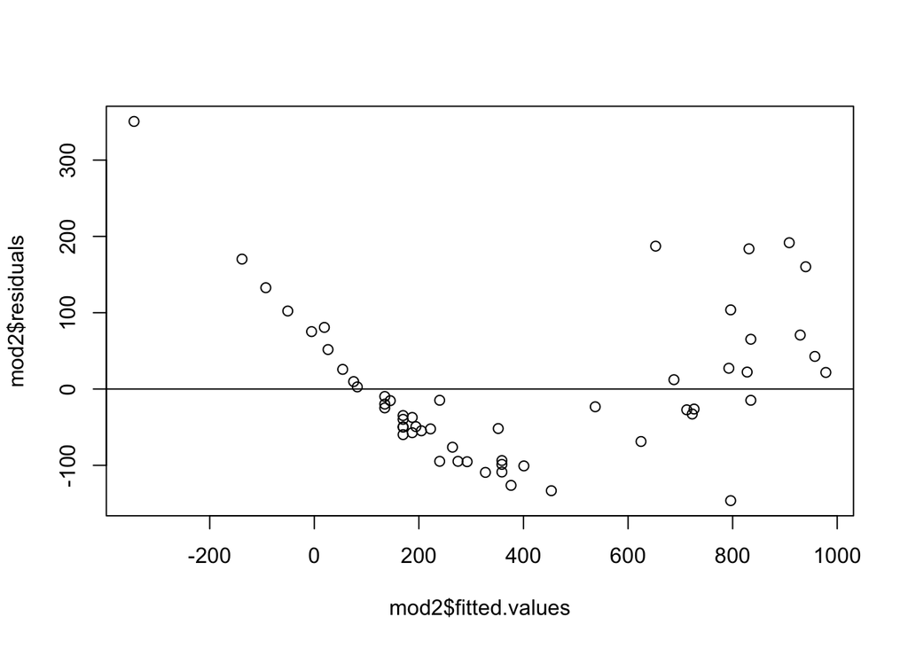

```r
# PLOT 2
plot(mod2$residuals~mod2$fitted.values)
abline(0,0)
```

(PART A)

```r
# (PART B)

mod3 = lm(log(Weight)~log(Length), data=Perch)
summary(mod3)
```

```
##
## Call:
## lm(formula = log(Weight) ~ log(Length), data = Perch)
##
## Residuals:
##      Min       1Q   Median       3Q      Max
## -0.21976 -0.07130 -0.00080  0.03965  0.36650
##
## Coefficients:
##             Estimate Std. Error t value Pr(>|t|)
## (Intercept) -5.07884    0.15212  -33.39   <2e-16 ***
## log(Length)  3.16269    0.04542   69.64   <2e-16 ***
## ---
## Signif. codes:  0 '***' 0.001 '**' 0.01 '*' 0.05 '.' 0.1 ' ' 1
##
## Residual standard error: 0.1157 on 54 degrees of freedom
## Multiple R-squared:  0.989,  Adjusted R-squared:  0.9888
## F-statistic:  4849 on 1 and 54 DF,  p-value: < 2.2e-16
```

```r
exp(-5.07884) #0.006227128
```

```
## [1] 0.006227128
```

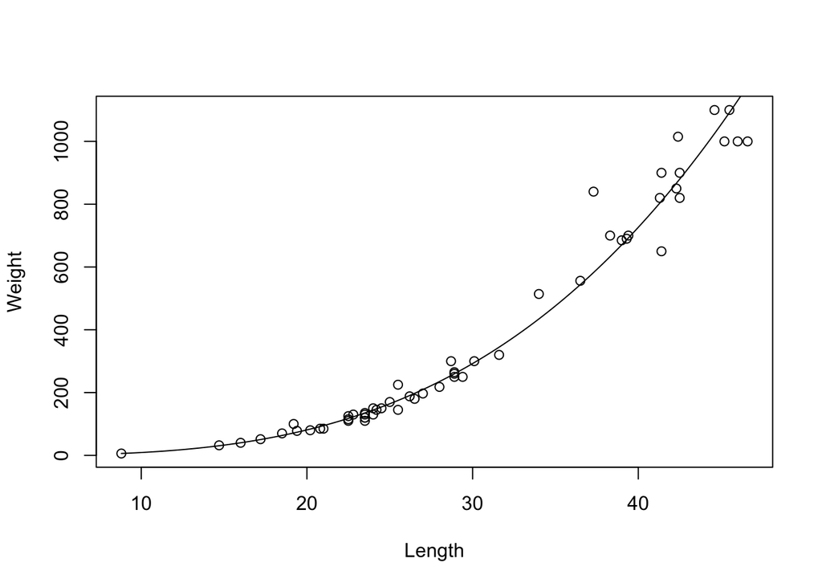

```r
plot(Weight~Length, data=Perch)
curve(0.006227128*(x^3.16269), add=TRUE)
```

(PART B) CALCULATIONS

log(Weight) = -5.07884 + 3.16269*log(Length) Weight = e ^(-5.07884 + 3.16269(log(Length)) Weight = e ^(-5.07884) e ^((3.16269)(log(Length)) Weight = e ^(-5.07884) e ^(log(Lengtht ^ 3.16269)) Weight = e ^(-5.07884) (Length ^ 3.16269)

Weight = 0.006227128(Length ^ 3.16269)

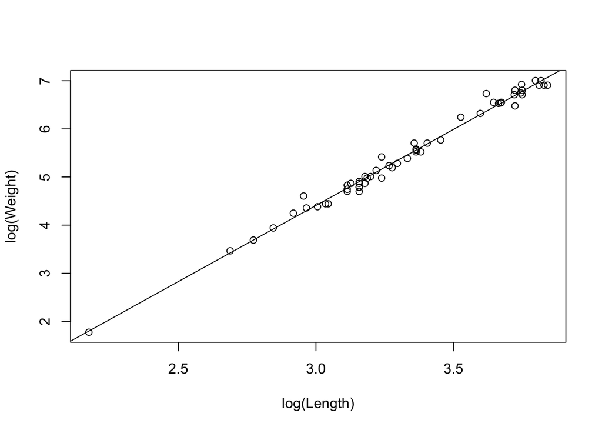

```r
# (PART C)

# PLOT 1 (Check for linearity, constant variance)
plot(log(Weight)~log(Length), data=Perch)
abline(mod3)
```

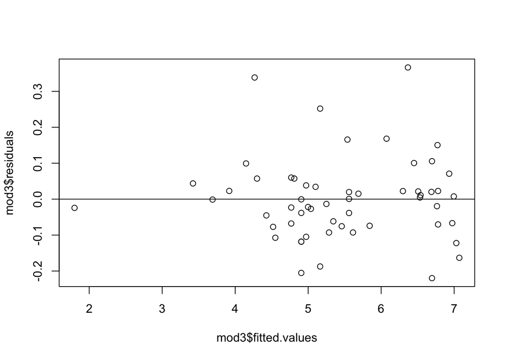

```r
# PLOT 2 (Check for zero mean)
plot(mod3$residuals~mod3$fitted.values)
abline(0,0)
```

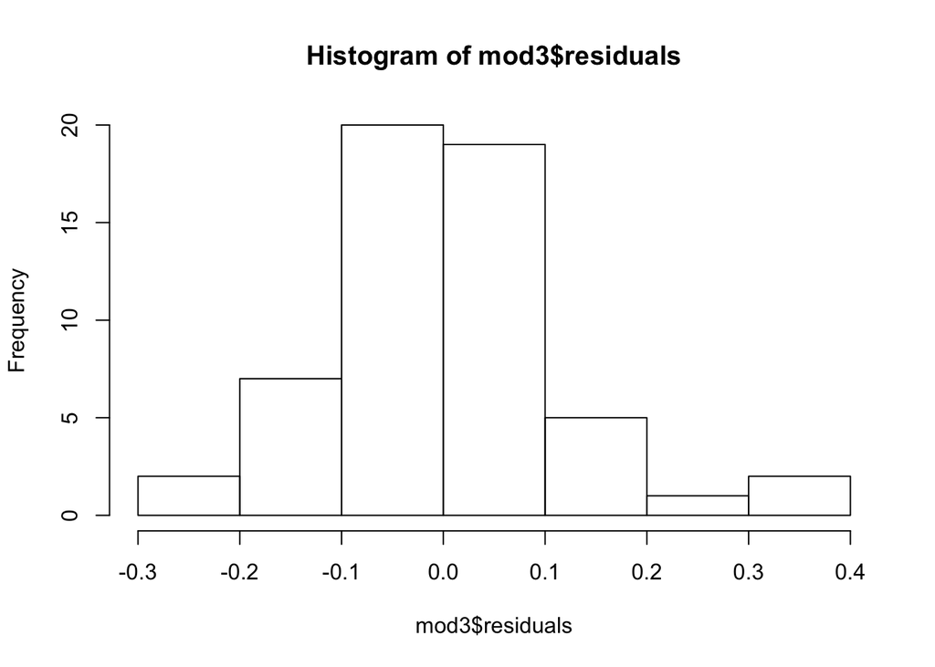

```r
# PLOT 3 (Check for independence, normal residuals)
hist(mod3$residuals)
```

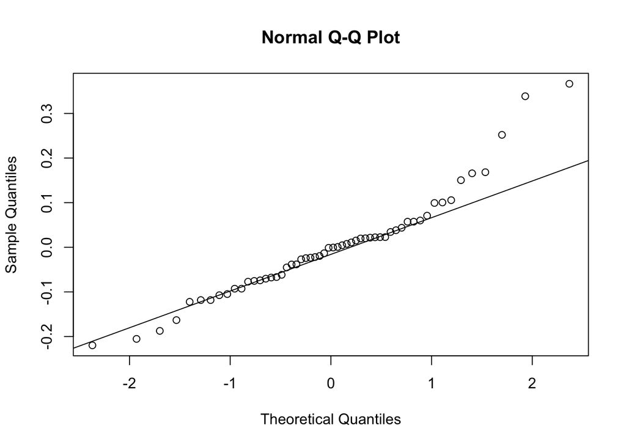

```r
# PLOT 4 (Check for independence, normal residuals)
qqnorm(mod3$residuals)
qqline(mod3$residuals)
```

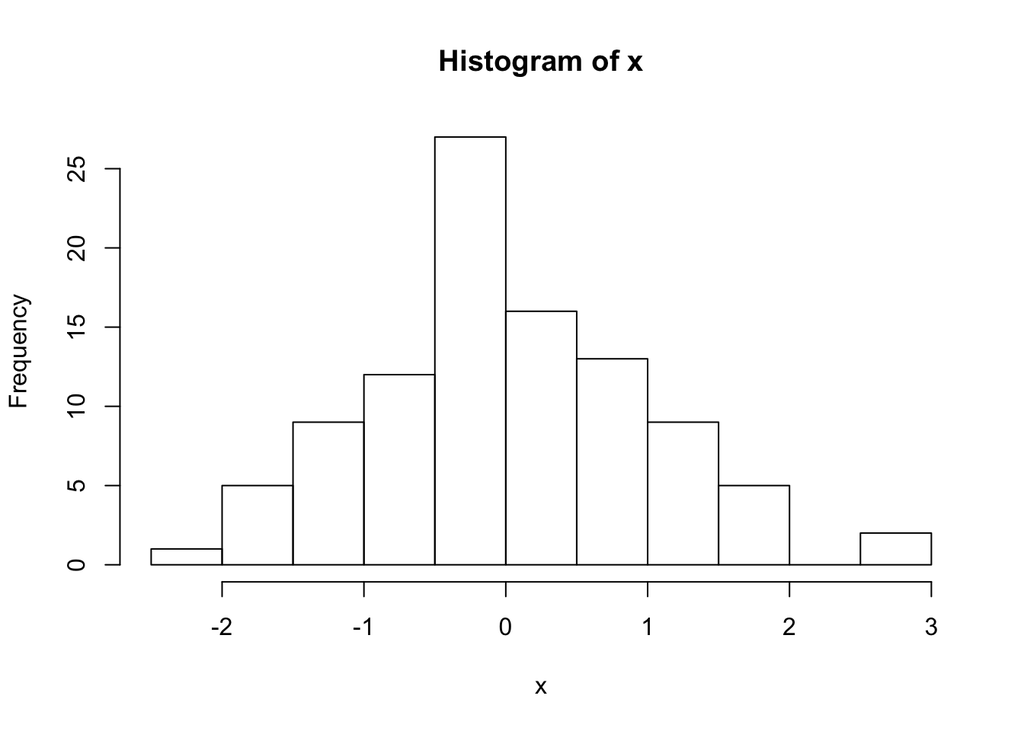

```r
# PLOT 5 (Check for normality)
set.seed(123218)
x = sort(rnorm(99,0,1))
hist(x)
```

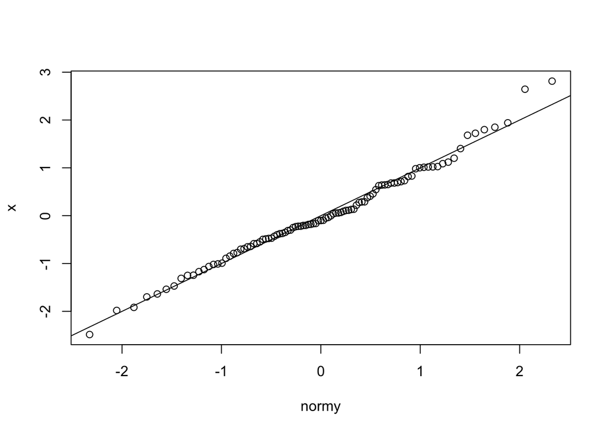

```r
# PLOT 6 (Check for normality)
y = c(1:99)
normy = qnorm(y/100)
plot(x~normy)
abline(0,1)
```

(PART C)

(PART D)

Weight = 0.006227128(Length ^ 3.16269) Weight = 0.006227128((19) ^ 3.16269) = 68.9586926 g ~ about 69 grams

—————- END PERCH SECTION ————–